# Reproducible estimation for the vec-spARCH model

Corrected QML, Monte Carlo inference, and empirical estimation

Author

Philipp Otto

Published

August 19, 2026

## 1 Overview

This document provides a reproducible implementation of the multivariate spatial and spatiotemporal ARCH (vec-spARCH) model introduced in Otto (2024), together with the corrected Gaussian quasi-log-likelihood and the additional inferential analysis reported in the accompanying corrigendum.

The main correction concerns the normalisation of the Gaussian quasi-log-likelihood. In the original article, both parameter-dependent terms, namely the log-determinant term and the quadratic residual term, were divided by the combined dimension $np$. This does not change the maximiser of the criterion, because the parameter-dependent part is multiplied by a common positive constant. It does, however, rescale the curvature of the criterion and therefore affects inverse-Hessian covariance estimates and the corresponding standard errors.

The corrected implementation below separates three questions:

1. **Point estimation.** The corrected and originally normalised criteria have the same theoretical maximiser.
2. **Hessian-based inference.** The inverse-Hessian covariance matrix from the original normalisation is too large by the factor $np$, and the corresponding standard errors are too large by the factor $\sqrt{np}$.
3. **QML-robust inference.** Since the transformed innovations are not Gaussian, sandwich covariance estimates are also reported as a robustness check.

The document additionally reproduces the Monte Carlo design of the original article, computes Monte Carlo standard deviations, standard-error calibration ratios, and 95% coverage probabilities, and provides code for the empirical estimator with variable-specific intercepts.

### 1.1 Main findings reproduced by the corrigendum

The corrected likelihood normalisation leaves the QML point estimates essentially unchanged, but substantially reduces the Hessian-based standard errors. In the Berlin real-estate application this strengthens the inferential conclusions: temporal dependence remains stronger than spatial dependence, but the corrected inference provides evidence for instantaneous spatial cross-variable interactions in addition to temporally lagged cross-variable interactions.

The Monte Carlo study shows that the corrected Hessian-based standard errors are generally of the right order of magnitude relative to the empirical Monte Carlo standard deviation. The largest deviations occur for some zero temporal cross-effects and for the intercept and selected spatial coefficients in the purely spatial Model B. Sandwich-based standard errors behave very similarly to the inverse-Hessian standard errors.

A special feature of Model B is that $\Pi_0=0$. With a spatially constant intercept and a row-standardised spatial weights matrix, the unconditional mean belongs to the constant spatial subspace. The mean alone therefore does not separately identify the intercept and $\Psi$; their separation additionally relies on the spatial covariance structure and the Jacobian term of the QML criterion. This helps explain the stronger finite-sample interaction between the corresponding estimates in that design.

## 2 Model and corrected quasi-log-likelihood

Let

$$\ddot{\mathbf Y}_t
=
\operatorname{vec}\!\left(\mathbf Y_t^{(\ln,2)}\right),
\qquad
\mathbf S_{np}
=
\mathbf I_{np}-\mathbf\Psi^\prime\otimes\mathbf W,$$

and define

$$\mathbf r_t(\boldsymbol\vartheta)
=
\mathbf S_{np}\ddot{\mathbf Y}_t
-
\operatorname{vec}(\widetilde{\mathbf A})
-
(\mathbf\Pi^\prime\otimes\mathbf I_n)
\ddot{\mathbf Y}_{t-1}.$$

For $T$ conditional transitions, the correctly scaled Gaussian quasi-log-likelihood is

$$\ell_{nT}^{\mathrm{cor}}(\boldsymbol\vartheta\mid\mathbf Y_0)
=
-\frac{Tnp}{2}\log(2\pi)
-\frac{Tnp}{2}\log(\sigma_u^2)
+T\log|\mathbf S_{np}|
-\frac{1}{2\sigma_u^2}\sum_{t=1}^T
\mathbf r_t(\boldsymbol\vartheta)^\prime\mathbf r_t(\boldsymbol\vartheta).$$

In the implementation below, the first observed time point is conditioned upon, so an array containing `TT` observations contributes `TT - 1` conditional likelihood terms.

If the originally normalised criterion is denoted by $\ell^{\mathrm{old}}_{nT}$, then

$$\ell^{\mathrm{old}}_{nT}(\boldsymbol\vartheta)
=
\frac{1}{np}\ell^{\mathrm{cor}}_{nT}(\boldsymbol\vartheta)+C,$$

where $C$ is independent of $\boldsymbol\vartheta$. Consequently,

$$\arg\max_{\boldsymbol\vartheta}\ell^{\mathrm{old}}_{nT}
=
\arg\max_{\boldsymbol\vartheta}\ell^{\mathrm{cor}}_{nT}.$$

For the Hessians,

$$\nabla^2\ell^{\mathrm{old}}_{nT}
=
\frac{1}{np}\nabla^2\ell^{\mathrm{cor}}_{nT},$$

and hence

$$\widehat{\operatorname{Var}}_{\mathrm{cor}}(\widehat{\boldsymbol\vartheta})
=
\frac{1}{np}\widehat{\operatorname{Var}}_{\mathrm{old}}(\widehat{\boldsymbol\vartheta}),
\qquad
\operatorname{se}_{\mathrm{cor}}
=
\frac{1}{\sqrt{np}}\operatorname{se}_{\mathrm{old}}.$$

For standard normal innovations,

$$E(\log\varepsilon^2)=\psi(1/2)+\log 2=-\gamma-\log 2,$$

and

$$\sigma_u^2=\operatorname{Var}(\log\varepsilon^2)=\psi_1(1/2)=\frac{\pi^2}{2}.$$

## 3 Reproducibility note for the $t_3$ simulations

The historical simulation code used raw $t_3$ innovations. Such innovations have variance 3, whereas the model formulation normalises the innovation variance to one. This document therefore exposes the choice explicitly through the parameter `standardise_t`.

- `standardise_t: false` reproduces the historical simulation convention, with $E(\log\varepsilon^2)=\log 3-2$.
- `standardise_t: true` uses $\varepsilon=T_3/\sqrt{3}$, so that $\operatorname{Var}(\varepsilon)=1$ and $E(\log\varepsilon^2)=-2$.

The variance of $\log\varepsilon^2$ is unchanged by this rescaling:

$$\operatorname{Var}(\log\varepsilon^2)=\pi^2-4.$$

For exact reproduction of the historical Monte Carlo output, keep the default `standardise_t: false`. For a simulation aligned exactly with the unit-variance innovation convention of the model, set it to `true`.

## 4 Packages

```r
required_packages <- c(
  "spdep", "Rsolnp", "numDeriv",
  "ggplot2", "dplyr", "tidyr", "parallel"
)

missing_packages <- required_packages[
  !vapply(required_packages, requireNamespace, logical(1), quietly = TRUE)
]

if (length(missing_packages) > 0) {
  stop(
    "Please install the following packages before rendering: ",
    paste(missing_packages, collapse = ", ")
  )
}

library(spdep)
library(Rsolnp)
library(numDeriv)
library(ggplot2)
library(dplyr)
library(tidyr)
library(parallel)
```

## 5 Helper functions and innovation moments

```r
logsq <- function(x) log(x^2)
logsq_back <- function(x, sgn) sgn * sqrt(exp(x))
vec <- function(x) as.vector(x)

innovation_spec <- function(
    errortype = c("norm", "t"),
    standardise_t = params$standardise_t
) {
  errortype <- match.arg(errortype)

  if (errortype == "norm") {
    return(list(
      generator = function(n, p) array(rnorm(n * p), dim = c(n, p)),
      E_logsq = digamma(0.5) + log(2),
      sig_u2 = trigamma(0.5)
    ))
  }

  if (isTRUE(standardise_t)) {
    generator <- function(n, p) {
      array(rt(n * p, df = 3) / sqrt(3), dim = c(n, p))
    }
    E_logsq <- -2
  } else {
    generator <- function(n, p) {
      array(rt(n * p, df = 3), dim = c(n, p))
    }
    E_logsq <- log(3) - 2
  }

  list(
    generator = generator,
    E_logsq = E_logsq,
    sig_u2 = pi^2 - 4
  )
}
```

## 6 Simulation of the vec-spARCH process

The default burn-in is 20 iterations to reproduce the historical simulation design. For new applications, a longer burn-in can be supplied through `burn_in`.

```r
simulate_vec_spARCH <- function(
    n, t, p, W, parameters,
    burn_in = 20,
    standardise_t = params$standardise_t
) {
  if (!all(dim(W) == c(n, n))) stop("Dimension of W is incompatible with n.")
  if (is.null(parameters$a)) stop("parameters$a must be supplied.")
  if (!all(dim(parameters$Psi) == c(p, p))) stop("parameters$Psi must be p x p.")
  if (!all(dim(parameters$Pi) == c(p, p))) stop("parameters$Pi must be p x p.")

  spec <- innovation_spec(parameters$errortype, standardise_t)
  err_distr <- spec$generator
  E_logsq_errors <- spec$E_logsq

  Psi <- parameters$Psi
  Pi <- parameters$Pi
  A <- matrix(parameters$a, nrow = n, ncol = p)
  A_tilde <- A + E_logsq_errors

  S <- diag(n * p) - kronecker(t(Psi), W)
  S_inv <- solve(S)

  eps <- err_distr(n, p)
  Y_lagged <- eps

  simulate_one <- function(Y_lagged) {
    eps <- err_distr(n, p)
    u <- logsq(eps) - E_logsq_errors

    vec_log_y2 <- S_inv %*% (
      vec(A_tilde) +
        kronecker(t(Pi), diag(n)) %*% vec(logsq(Y_lagged)) +
        vec(u)
    )

    y <- logsq_back(vec_log_y2, sign(vec(eps)))
    Y_new <- matrix(y, nrow = n, ncol = p)

    log_h <- matrix(vec_log_y2, nrow = n, ncol = p) - logsq(eps)
    H_new <- exp(log_h)

    list(Y = Y_new, H = H_new)
  }

  for (b in seq_len(burn_in)) {
    step <- simulate_one(Y_lagged)
    Y_lagged <- step$Y
  }

  Y <- array(NA_real_, dim = c(n, p, t))
  H <- array(NA_real_, dim = c(n, p, t))

  for (tt in seq_len(t)) {
    step <- simulate_one(Y_lagged)
    Y[, , tt] <- step$Y
    H[, , tt] <- step$H
    Y_lagged <- step$Y
  }

  list(
    Y = Y,
    H = H,
    parameters = parameters,
    E_logsq_errors = E_logsq_errors,
    sig_u2 = spec$sig_u2
  )
}
```

## 7 Time-specific QML score contributions

The score function supports both a single common intercept, as used in the Monte Carlo study, and $p$ variable-specific intercepts, as used in the empirical application. The returned matrix has one row for each conditional transition and is used to construct the outer-product matrix $J$ in the sandwich covariance estimator.

```r
qml_score_time <- function(
    par, Y, W, sig_u2,
    intercept = c("scalar", "vector")
) {
  intercept <- match.arg(intercept)

  n <- dim(Y)[1]
  p <- dim(Y)[2]
  TT <- dim(Y)[3]
  np <- n * p

  q <- if (intercept == "scalar") 1L else p

  idx_a <- seq_len(q)
  idx_psi <- q + seq_len(p^2)
  idx_pi <- q + p^2 + seq_len(p^2)

  a_tilde <- par[idx_a]
  Psi <- matrix(par[idx_psi], p, p)
  Pi <- matrix(par[idx_pi], p, p)

  if (intercept == "scalar") {
    A_tilde <- matrix(a_tilde, nrow = n, ncol = p)
    X_a <- matrix(1, nrow = np, ncol = 1)
  } else {
    A_tilde <- matrix(rep(a_tilde, each = n), nrow = n, ncol = p)
    X_a <- kronecker(diag(p), matrix(1, nrow = n, ncol = 1))
  }

  S <- diag(np) - kronecker(t(Psi), W)
  S_inv <- solve(S)

  K_list <- vector("list", p^2)
  tr_term <- numeric(p^2)
  counter <- 1L

  # Column-major order: psi_11, psi_21, ..., psi_p1, psi_12, ...
  for (j in seq_len(p)) {
    for (i in seq_len(p)) {
      Eji <- matrix(0, p, p)
      Eji[j, i] <- 1
      K <- kronecker(Eji, W)
      K_list[[counter]] <- K
      tr_term[counter] <- sum(S_inv * t(K))
      counter <- counter + 1L
    }
  }

  scores <- matrix(NA_real_, nrow = TT - 1, ncol = q + 2 * p^2)

  for (tt in 2:TT) {
    z_t <- vec(logsq(Y[, , tt]))
    Y_lag <- logsq(Y[, , tt - 1])
    X_pi <- kronecker(diag(p), Y_lag)

    r_t <- S %*% z_t - vec(A_tilde) - X_pi %*% vec(Pi)
    score <- numeric(q + 2 * p^2)

    score[idx_a] <- -as.vector(crossprod(X_a, r_t)) / sig_u2

    for (k in seq_len(p^2)) {
      Kz <- K_list[[k]] %*% z_t
      score[idx_psi[k]] <-
        tr_term[k] - drop(crossprod(r_t, Kz)) / sig_u2
    }

    score[idx_pi] <- -as.vector(crossprod(X_pi, r_t)) / sig_u2
    scores[tt - 1, ] <- score
  }

  scores
}
```

## 8 QML estimator

The same estimator is used for the Monte Carlo study and the empirical application. Set `intercept = "scalar"` for the simulation design and `intercept = "vector"` for variable-specific empirical intercepts. The optimiser works with $\widetilde A$; the returned `theta` transforms the intercept back to $A$ using $E(\log\varepsilon^2)$.

```r
qml_vec_spARCH <- function(
    Y, W, parameters,
    intercept = c("scalar", "vector"),
    start = NULL,
    standardise_t = params$standardise_t,
    trace = FALSE
) {
  intercept <- match.arg(intercept)

  dimY <- dim(Y)
  n <- dimY[1]
  p <- dimY[2]
  TT <- dimY[3]
  np <- n * p

  if (!all(dim(W) == c(n, n))) stop("Dimension of W is incompatible with Y.")

  spec <- innovation_spec(parameters$errortype, standardise_t)
  E_logsq_errors <- spec$E_logsq
  sig_u2 <- spec$sig_u2

  q <- if (intercept == "scalar") 1L else p

  unpack_parameters <- function(pars) {
    idx_a <- seq_len(q)
    idx_psi <- q + seq_len(p^2)
    idx_pi <- q + p^2 + seq_len(p^2)
    a_tilde <- pars[idx_a]

    if (intercept == "scalar") {
      A_tilde <- matrix(a_tilde, nrow = n, ncol = p)
    } else {
      A_tilde <- matrix(rep(a_tilde, each = n), nrow = n, ncol = p)
    }

    list(
      idx_a = idx_a,
      idx_psi = idx_psi,
      idx_pi = idx_pi,
      a_tilde = a_tilde,
      A_tilde = A_tilde,
      Psi = matrix(pars[idx_psi], p, p),
      Pi = matrix(pars[idx_pi], p, p)
    )
  }

  negative_qml <- function(pars, Y, W, sig_u2) {
    par_list <- unpack_parameters(pars)
    S <- diag(np) - kronecker(t(par_list$Psi), W)

    detS <- determinant(S, logarithm = TRUE)
    log_det_S <- as.numeric(detS$modulus)
    if (!is.finite(log_det_S)) return(1e12)

    sum_res2 <- 0

    for (tt in 2:TT) {
      r_t <- S %*% vec(logsq(Y[, , tt])) -
        vec(par_list$A_tilde) -
        kronecker(diag(p), logsq(Y[, , tt - 1])) %*% vec(par_list$Pi)

      if (any(!is.finite(r_t))) return(1e12)
      sum_res2 <- sum_res2 + sum(r_t^2)
    }

    n_transitions <- TT - 1

    ll <-
      -n_transitions * np / 2 * log(2 * pi) -
      n_transitions * np / 2 * log(sig_u2) +
      n_transitions * log_det_S -
      sum_res2 / (2 * sig_u2)

    -ll
  }

  residuals_fun <- function(pars) {
    par_list <- unpack_parameters(pars)
    S <- diag(np) - kronecker(t(par_list$Psi), W)
    U <- matrix(NA_real_, nrow = np, ncol = TT - 1)

    for (tt in 2:TT) {
      U[, tt - 1] <- S %*% vec(logsq(Y[, , tt])) -
        vec(par_list$A_tilde) -
        kronecker(diag(p), logsq(Y[, , tt - 1])) %*% vec(par_list$Pi)
    }

    U
  }

  if (is.null(start)) {
    start_a <- if (intercept == "scalar") 1 else rep(1, p)

    if (p == 2) {
      start_Psi <- matrix(c(0.5, 0.1, 0.1, 0.5), p, p)
      start_Pi <- matrix(c(0.3, 0, 0, 0.3), p, p)
    } else {
      start_Psi <- diag(0.2, p)
      start_Pi <- diag(0.2, p)
    }

    start <- c(start_a, vec(start_Psi), vec(start_Pi))
  }

  out <- solnp(
    pars = start,
    fun = negative_qml,
    Y = Y,
    W = W,
    sig_u2 = sig_u2,
    control = list(trace = trace)
  )

  par_opt <- out$pars
  par_list <- unpack_parameters(par_opt)

  H <- numDeriv::hessian(
    func = negative_qml,
    x = par_opt,
    Y = Y,
    W = W,
    sig_u2 = sig_u2
  )
  H <- (H + t(H)) / 2

  V_hessian <- tryCatch(
    solve(H),
    error = function(e) matrix(NA_real_, nrow(H), ncol(H))
  )

  stderr_hessian <- rep(NA_real_, nrow(H))
  if (all(is.finite(V_hessian))) {
    diag_v <- diag(V_hessian)
    keep <- diag_v > 0
    stderr_hessian[keep] <- sqrt(diag_v[keep])
  }

  score_t <- qml_score_time(
    par = par_opt,
    Y = Y,
    W = W,
    sig_u2 = sig_u2,
    intercept = intercept
  )

  J <- crossprod(score_t)
  V_sandwich <- V_hessian %*% J %*% V_hessian
  V_sandwich <- (V_sandwich + t(V_sandwich)) / 2

  stderr_sandwich <- rep(NA_real_, nrow(V_sandwich))
  if (all(is.finite(V_sandwich))) {
    diag_v <- diag(V_sandwich)
    keep <- diag_v > 0
    stderr_sandwich[keep] <- sqrt(diag_v[keep])
  }

  a_est <- par_list$a_tilde - E_logsq_errors

  if (intercept == "scalar") {
    A_est <- matrix(a_est, nrow = n, ncol = p)
  } else {
    A_est <- matrix(rep(a_est, each = n), nrow = n, ncol = p)
  }

  theta <- c(a_est, vec(par_list$Psi), vec(par_list$Pi))
  theta_tilde <- c(par_list$a_tilde, vec(par_list$Psi), vec(par_list$Pi))
  res <- residuals_fun(par_opt)

  list(
    theta = theta,
    theta_tilde = theta_tilde,
    par_opt = par_opt,
    a_est = a_est,
    a_tilde_est = par_list$a_tilde,
    A_est = A_est,
    A_tilde_est = par_list$A_tilde,
    Psi_est = par_list$Psi,
    Pi_est = par_list$Pi,
    H = H,
    vcov_hessian = V_hessian,
    stderr_hessian = stderr_hessian,
    score_t = score_t,
    J = J,
    vcov_sandwich = V_sandwich,
    stderr_sandwich = stderr_sandwich,
    ll = -tail(out$values, 1),
    residuals = res,
    var_res = mean(res^2, na.rm = TRUE),
    E_logsq_errors = E_logsq_errors,
    sig_u2 = sig_u2,
    intercept = intercept
  )
}
```

## 9 Minimal simulation example

```r
set.seed(1)

p <- 2
d <- 5
n <- d^2
TT <- 50

W <- nb2mat(
  cell2nb(d, d, type = "queen"),
  style = "W"
)

parameters <- list(
  a = 1,
  Psi = matrix(
    c(0.5, 0.1,
      0.1, 0.5),
    p, p
  ),
  Pi = matrix(
    c(0.3, 0,
      0, 0.3),
    p, p
  ),
  errortype = "norm"
)

# Simulate data
sim <- simulate_vec_spARCH(
  n = n,
  t = TT,
  p = p,
  W = W,
  parameters = parameters
)

# Estimate model
est <- qml_vec_spARCH(
  Y = sim$Y,
  W = W,
  parameters = parameters,
  intercept = "scalar"
)

# ------------------------------------------------------------
# Compare true and estimated parameters
# ------------------------------------------------------------

true_parameters <- c(
  parameters$a,
  vec(parameters$Psi),
  vec(parameters$Pi)
)

parameter_names <- c(
  "a",
  "psi_11", "psi_21", "psi_12", "psi_22",
  "pi_11",  "pi_21",  "pi_12",  "pi_22"
)

results <- data.frame(
  Parameter = parameter_names,
  True = true_parameters,
  Estimate = est$theta,
  SE_Hessian = est$stderr_hessian,
  SE_Sandwich = est$stderr_sandwich
)

results[, -1] <- round(results[, -1], 3)

results
```

```
  Parameter True Estimate SE_Hessian SE_Sandwich
1         a  1.0    1.002      0.073       0.057
2    psi_11  0.5    0.454      0.033       0.023
3    psi_21  0.1    0.073      0.041       0.038
4    psi_12  0.1    0.118      0.046       0.050
5    psi_22  0.5    0.472      0.030       0.032
6     pi_11  0.3    0.310      0.024       0.021
7     pi_21  0.0    0.042      0.024       0.022
8     pi_12  0.0   -0.022      0.026       0.024
9     pi_22  0.3    0.314      0.023       0.026
```

## 10 Monte Carlo design

The original simulation study considers three bivariate models:

$$\text{Model A:}\qquad
\Psi_0=
\begin{pmatrix}0.5&0.1\\0.1&0.5\end{pmatrix},
\qquad
\Pi_0=
\begin{pmatrix}0.3&0\\0&0.3\end{pmatrix},$$

$$\text{Model B:}\qquad
\Psi_0=
\begin{pmatrix}0.5&0.1\\0.1&0.5\end{pmatrix},
\qquad
\Pi_0=\mathbf 0,$$

and

$$\text{Model C:}\qquad
\Psi_0=
\begin{pmatrix}0.2&0.4\\0.4&0.2\end{pmatrix},
\qquad
\Pi_0=
\begin{pmatrix}0.3&0\\0&0.3\end{pmatrix}.$$

For all three models, $a_0=1$. The sample-size combinations are

$$(n,T)\in\{(25,30),(49,100),(100,200)\},$$

with row-standardised Queen contiguity weights and both normal and $t_3$ innovations.

```r
n_set <- c(25, 49, 100)
t_set <- c(30, 100, 200)
p_set <- 2

make_design <- function(model, n, error) {
  p <- p_set
  parameters <- list(a = 1)

  if (model == "M1") {
    parameters$Psi <- matrix(c(0.5, 0.1, 0.1, 0.5), p, p)
    parameters$Pi <- matrix(c(0.3, 0, 0, 0.3), p, p)
  }

  if (model == "M2") {
    parameters$Psi <- matrix(c(0.5, 0.1, 0.1, 0.5), p, p)
    parameters$Pi <- matrix(0, p, p)
  }

  if (model == "M3") {
    parameters$Psi <- matrix(c(0.2, 0.4, 0.4, 0.2), p, p)
    parameters$Pi <- matrix(c(0.3, 0, 0, 0.3), p, p)
  }

  parameters$errortype <- error

  W <- nb2mat(
    cell2nb(sqrt(n), sqrt(n), type = "queen"),
    style = "W"
  )

  list(
    parameters = parameters,
    W = W,
    dgp = c(parameters$a, vec(parameters$Psi), vec(parameters$Pi))
  )
}
```

## 11 Parallel Monte Carlo implementation

The full simulation is not run automatically when rendering the web page. Run the following chunk interactively, or change its chunk option to `eval: true`, to generate the 1000-replication result file.

```r
run_replication <- function(
    i, n, TT, p, W, parameters, dgp,
    seed_base, standardise_t
) {
  set.seed(seed_base + i)

  tryCatch({
    sim <- simulate_vec_spARCH(
      n = n,
      t = TT,
      p = p,
      W = W,
      parameters = parameters,
      standardise_t = standardise_t
    )

    est <- qml_vec_spARCH(
      Y = sim$Y,
      W = W,
      parameters = parameters,
      intercept = "scalar",
      standardise_t = standardise_t
    )

    list(
      success = TRUE,
      replication = i,
      output = est,
      n = n,
      t = TT,
      p = p,
      dgp = dgp,
      error = parameters$errortype
    )
  }, error = function(e) {
    list(
      success = FALSE,
      replication = i,
      message = conditionMessage(e),
      n = n,
      t = TT,
      p = p,
      dgp = dgp,
      error = parameters$errortype
    )
  })
}
```

```r
if (isTRUE(params$run_full_mc)) {

m <- params$mc_replications
available_cores <- max(1, parallel::detectCores() - 2)
n_cores <- min(params$cores, available_cores)

cat("Using", n_cores, "cores\n")

cl <- makeCluster(n_cores)

clusterEvalQ(cl, {
  library(spdep)
  library(Rsolnp)
  library(numDeriv)
  NULL
})

clusterExport(
  cl,
  varlist = c(
    "logsq", "logsq_back", "vec",
    "innovation_spec", "simulate_vec_spARCH",
    "qml_score_time", "qml_vec_spARCH",
    "run_replication"
  ),
  envir = environment()
)

M1 <- M2 <- M3 <- vector("list", length = 6)
counter <- 1L

for (size in seq_along(n_set)) {
  n <- n_set[size]
  TT <- t_set[size]
  p <- p_set

  for (error_distrib in c("norm", "t")) {
    for (model in c("M1", "M2", "M3")) {
      design <- make_design(model = model, n = n, error = error_distrib)

      cat(
        "\nRunning", model,
        "| n =", n,
        "| T =", TT,
        "| error =", error_distrib,
        "| replications =", m, "\n"
      )

      result_list <- parLapplyLB(
        cl,
        X = seq_len(m),
        fun = run_replication,
        n = n,
        TT = TT,
        p = p,
        W = design$W,
        parameters = design$parameters,
        dgp = design$dgp,
        seed_base = 100000 * counter,
        standardise_t = params$standardise_t
      )

      if (model == "M1") M1[[counter]] <- result_list
      if (model == "M2") M2[[counter]] <- result_list
      if (model == "M3") M3[[counter]] <- result_list

      save(M1, M2, M3, file = "Output_vecspARCH_MC_temp.rda")
    }

    counter <- counter + 1L
  }
}

stopCluster(cl)

save(M1, M2, M3, file = "Output_vecspARCH_MC_1000.rda")

} else {
  message("Full Monte Carlo simulation skipped. Set run_full_mc: true to run it.")
}
```

### 11.1 Loading pre-computed output

For a website render, run the full simulation once, save `Output_vecspARCH_MC_1000.rda` in the same directory, and let the page load the stored results.

```r
result_file <- "Output_vecspARCH_MC_1000.rda"

if (file.exists(result_file)) load(result_file)

have_mc_results <- all(
  c("M1", "M2", "M3") %in% ls(envir = environment())
)
```

## 12 Monte Carlo summaries

```r
par_names <- c(
  "a",
  "psi_11", "psi_21", "psi_12", "psi_22",
  "pi_11", "pi_21", "pi_12", "pi_22"
)

successful_results <- function(results) {
  Filter(function(x) isTRUE(x$success), results)
}

summarise_MC <- function(results, model, error, n, TT, par_names) {
  results <- successful_results(results)
  if (length(results) == 0) stop("No successful Monte Carlo replications.")

  theta <- do.call(rbind, lapply(results, function(x) x$output$theta))
  se_hessian <- do.call(rbind, lapply(results, function(x) x$output$stderr_hessian))
  se_sandwich <- do.call(rbind, lapply(results, function(x) x$output$stderr_sandwich))

  dgp <- results[[1]]$dgp
  p <- results[[1]]$p

  error_mat <- sweep(theta, 2, dgp, "-")
  z <- qnorm(0.975)

  coverage_hessian <- colMeans(
    abs(error_mat) <= z * se_hessian,
    na.rm = TRUE
  )

  coverage_sandwich <- colMeans(
    abs(error_mat) <= z * se_sandwich,
    na.rm = TRUE
  )

  se_old <- sqrt(n * p) * se_hessian

  coverage_old <- colMeans(
    abs(error_mat) <= z * se_old,
    na.rm = TRUE
  )

  MCSD <- apply(theta, 2, sd, na.rm = TRUE)
  mean_se_hessian <- colMeans(se_hessian, na.rm = TRUE)
  mean_se_sandwich <- colMeans(se_sandwich, na.rm = TRUE)

  data.frame(
    model = model,
    error = error,
    n = n,
    T = TT,
    parameter = par_names,
    true = dgp,
    bias = colMeans(error_mat, na.rm = TRUE),
    rmse = sqrt(colMeans(error_mat^2, na.rm = TRUE)),
    MCSD = MCSD,
    mean_SE_H = mean_se_hessian,
    SE_ratio_H = mean_se_hessian / MCSD,
    coverage_H = coverage_hessian,
    mean_SE_S = mean_se_sandwich,
    SE_ratio_S = mean_se_sandwich / MCSD,
    coverage_S = coverage_sandwich,
    coverage_old = coverage_old,
    valid_H = colSums(is.finite(se_hessian)),
    valid_S = colSums(is.finite(se_sandwich))
  )
}
```

```r
if (have_mc_results) {
  MC_summary <- data.frame()

  for (model in c("M1", "M2", "M3")) {
    object <- get(model)

    for (err in 1:2) {
      for (size in seq_along(n_set)) {
        ind_model <- 2 * (size - 1) + err
        error_name <- if (err == 1) "Normal" else "t3"

        tmp <- summarise_MC(
          results = object[[ind_model]],
          model = model,
          error = error_name,
          n = n_set[size],
          TT = t_set[size],
          par_names = par_names
        )

        MC_summary <- bind_rows(MC_summary, tmp)
      }
    }
  }

  MC_summary <- MC_summary %>%
    mutate(
      model = factor(
        model,
        levels = c("M1", "M2", "M3"),
        labels = c("Model A", "Model B", "Model C")
      ),
      T_fac = factor(T),
      bias_ratio_H = bias / mean_SE_H,
      bias_ratio_S = bias / mean_SE_S
    )
}
```

### 12.1 Numerical summary

```r
if (have_mc_results) {
  MC_summary %>%
    select(
      model, error, n, T, parameter,
      bias, rmse, MCSD,
      mean_SE_H, SE_ratio_H, coverage_H,
      mean_SE_S, SE_ratio_S, coverage_S,
      coverage_old
    ) %>%
    mutate(across(where(is.numeric), ~ round(.x, 4)))
}
```

```
      model  error   n   T parameter    bias   rmse   MCSD mean_SE_H SE_ratio_H
1   Model A Normal  25  30         a -0.0642 0.1508 0.1371    0.1165     0.8497
2   Model A Normal  25  30    psi_11 -0.0081 0.0420 0.0414    0.0417     1.0066
3   Model A Normal  25  30    psi_21 -0.0085 0.0579 0.0575    0.0579     1.0074
4   Model A Normal  25  30    psi_12 -0.0015 0.0626 0.0629    0.0585     0.9300
5   Model A Normal  25  30    psi_22 -0.0114 0.0439 0.0426    0.0414     0.9717
6   Model A Normal  25  30     pi_11 -0.0070 0.0310 0.0304    0.0317     1.0445
7   Model A Normal  25  30     pi_21  0.0023 0.0290 0.0290    0.0333     1.1483
8   Model A Normal  25  30     pi_12 -0.0016 0.0349 0.0350    0.0338     0.9647
9   Model A Normal  25  30     pi_22 -0.0062 0.0349 0.0345    0.0315     0.9131
10  Model A Normal  49 100         a -0.0165 0.0465 0.0437    0.0448     1.0261
11  Model A Normal  49 100    psi_11 -0.0008 0.0178 0.0179    0.0166     0.9294
12  Model A Normal  49 100    psi_21 -0.0012 0.0230 0.0231    0.0227     0.9829
13  Model A Normal  49 100    psi_12 -0.0007 0.0229 0.0230    0.0226     0.9856
14  Model A Normal  49 100    psi_22 -0.0034 0.0156 0.0152    0.0166     1.0902
```

[output cut: 311 more lines]

## 13 Monte Carlo figures

```r
model_cols <- c(
  "Model A" = "#D55E00",
  "Model B" = "#009E73",
  "Model C" = "#0072B2"
)

parameter_labeller <- as_labeller(
  c(
    "a" = "a",
    "pi_11" = "pi[11]",
    "pi_12" = "pi[12]",
    "pi_21" = "pi[21]",
    "pi_22" = "pi[22]",
    "psi_11" = "psi[11]",
    "psi_12" = "psi[12]",
    "psi_21" = "psi[21]",
    "psi_22" = "psi[22]"
  ),
  label_parsed
)

error_labeller <- as_labeller(
  c("Normal" = "Normal", "t3" = "t[3]"),
  label_parsed
)

plot_MC_measure <- function(data, measure, ylab, reference = NULL, ylim = NULL) {
  p <- ggplot(
    data,
    aes(
      x = n,
      y = .data[[measure]],
      colour = model,
      group = model
    )
  ) +
    geom_line(linewidth = 0.8, alpha = 0.95) +
    geom_point(aes(shape = T_fac), size = 2.5, stroke = 0.7) +
    facet_grid(
      error ~ parameter,
      scales = "free_y",
      labeller = labeller(
        error = error_labeller,
        parameter = parameter_labeller
      )
    ) +
    scale_colour_manual(values = model_cols) +
    scale_shape_manual(values = c("30" = 16, "100" = 17, "200" = 15)) +
    labs(
      x = "Number of spatial locations",
      y = ylab,
      colour = "Model",
      shape = "Number of time points"
    ) +
    theme_minimal(base_size = 11) +
    theme(
      legend.position = "bottom",
      panel.grid.minor = element_blank(),
      panel.grid.major.x = element_line(colour = "grey88", linewidth = 0.35),
      panel.grid.major.y = element_line(colour = "grey90", linewidth = 0.35),
      strip.background = element_rect(fill = "grey95", colour = NA),
      strip.text = element_text(face = "bold", size = 9)
    )

  if (!is.null(reference)) {
    p <- p + geom_hline(
      yintercept = reference,
      linetype = "dashed",
      colour = "grey35",
      linewidth = 0.55
    )
  }

  if (!is.null(ylim)) p <- p + coord_cartesian(ylim = ylim)
  p
}
```

### 13.1 RMSE

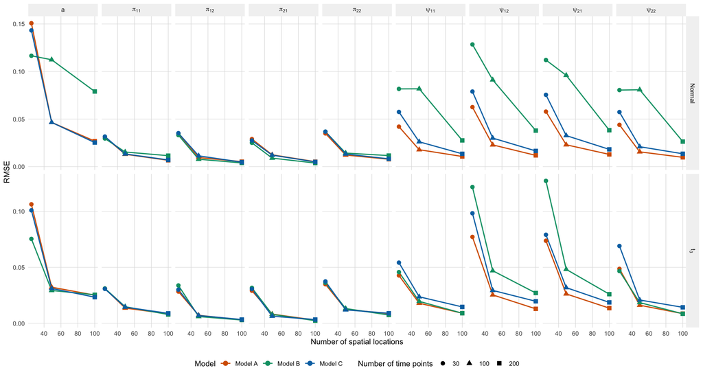

Root-mean-square errors of the QML estimates across the simulation settings. The colours distinguish Models A–C, while the symbols indicate the number of time points. The upper and lower panels correspond to standard normal and t3-distributed innovations, respectively.

```r
if (have_mc_results) {
  p_rmse <- plot_MC_measure(
    MC_summary,
    measure = "rmse",
    ylab = "RMSE"
  )
  p_rmse
}
```

### 13.2 Standard-error calibration

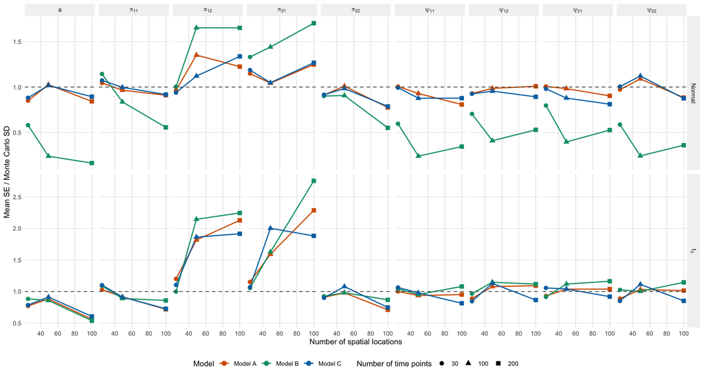

Ratio of the average Hessian-based standard error to the Monte Carlo standard deviation of the QML estimator. The horizontal dashed line indicates the reference value one.

```r
if (have_mc_results) {
  p_ratio_h <- plot_MC_measure(
    MC_summary,
    measure = "SE_ratio_H",
    ylab = "Mean SE / Monte Carlo SD",
    reference = 1
  )
  p_ratio_h
}
```

### 13.3 Coverage probabilities

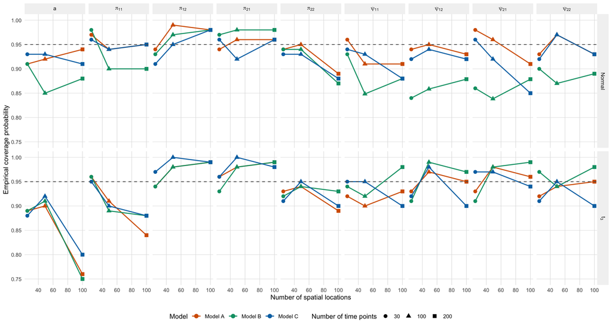

Empirical coverage probabilities of nominal 95% Wald confidence intervals based on the corrected Hessian. The horizontal dashed line indicates the nominal coverage probability of 0.95.

```r
if (have_mc_results) {
  p_cov_h <- plot_MC_measure(
    MC_summary,
    measure = "coverage_H",
    ylab = "Empirical coverage probability",
    reference = 0.95,
    ylim = c(0.75, 1)
  )
  p_cov_h
}
```

### 13.4 Saving the figures

```r
ggsave(
  "Results_MC_RMSE.pdf",
  p_rmse,
  width = 14,
  height = 7.5,
  units = "in",
  device = cairo_pdf
)

ggsave(
  "Results_MC_SE_ratio.pdf",
  p_ratio_h,
  width = 14,
  height = 7.5,
  units = "in",
  device = cairo_pdf
)

ggsave(
  "Results_MC_Coverage.pdf",
  p_cov_h,
  width = 14,
  height = 7.5,
  units = "in",
  device = cairo_pdf
)
```

## 14 Model B diagnostic

For Model B, the absence of temporal dependence makes the separation of the constant intercept and spatial autoregressive parameters more reliant on the spatial covariance structure. The following diagnostic reproduces the empirical correlation matrix among the estimated intercept and the four entries of $\Psi$ for the largest normal-error design.

```r
if (have_mc_results) {
  theta_B <- do.call(
    rbind,
    lapply(
      successful_results(M2[[5]]),
      function(x) x$output$theta
    )
  )

  round(cor(theta_B[, 1:5]), 3)
}
```

```
      [,1]  [,2]   [,3]   [,4]  [,5]
[1,] 1.000 0.770  0.483  0.521 0.734
[2,] 0.770 1.000  0.131  0.745 0.617
[3,] 0.483 0.131  1.000 -0.317 0.679
[4,] 0.521 0.745 -0.317  1.000 0.249
[5,] 0.734 0.617  0.679  0.249 1.000
```

## 15 Empirical application

The Berlin application uses $p=3$ variable-specific intercepts, so the estimator is called with `intercept = "vector"`. The current document does **not** include the original Berlin data. Once the empirical response array `Y_emp` and the corresponding row-standardised spatial weights matrix `W_emp` are available, the corrected estimator is run as follows.

```r
parameters_emp <- list(errortype = "norm")

est_emp <- qml_vec_spARCH(
  Y = Y_emp,
  W = W_emp,
  parameters = parameters_emp,
  intercept = "vector"
)

p <- dim(Y_emp)[2]

round(est_emp$a_tilde_est, 3)

round(
  matrix(est_emp$theta_tilde[(p + 1):(p^2 + p)], p, p),
  3
)

round(
  matrix(est_emp$theta_tilde[(p^2 + p + 1):(2 * p^2 + p)], p, p),
  3
)

round(est_emp$stderr_hessian, 3)
round(est_emp$stderr_sandwich, 3)
```

The corrigendum reports the estimated centred intercept $\widetilde A$ together with $\Psi$ and $\Pi$. The corresponding estimates are approximately

$$\widehat{\widetilde A}
=
(-4.731,\;0.226,\;-2.544)^\prime,$$

$$\widehat\Psi
=
\begin{pmatrix}
0.108 & 0.019 & -0.054\\
0.014 & 0.140 & 0.000\\
-0.084 & 0.013 & 0.118
\end{pmatrix},$$

and

$$\widehat\Pi
=
\begin{pmatrix}
0.581 & 0.128 & -0.014\\
0.082 & 0.552 & 0.026\\
-0.027 & 0.080 & 0.610
\end{pmatrix}.$$

The corrected Hessian-based standard errors are much smaller than those reported under the original likelihood normalisation. All displayed dependence coefficients are statistically significant at the 5% level except the spatial cross-effect whose estimate is essentially zero.

## 16 Stability representation

Let

$$\mathbf B
=
\mathbf S_{np}^{-1}(\mathbf\Pi^\prime\otimes\mathbf I_n),
\qquad
\mathbf c
=
\mathbf S_{np}^{-1}\operatorname{vec}(\widetilde{\mathbf A}),
\qquad
\mathbf e_t
=
\mathbf S_{np}^{-1}\operatorname{vec}(\mathbf U_t).$$

Then

$$\ddot{\mathbf Y}_t
=
\mathbf c+\mathbf B\ddot{\mathbf Y}_{t-1}+\mathbf e_t,$$

and, if $\rho(\mathbf B)<1$,

$$\ddot{\mathbf Y}_t
=
(\mathbf I_{np}-\mathbf B)^{-1}\mathbf c
+
\sum_{k=0}^{\infty}\mathbf B^k\mathbf e_{t-k}.$$

A convenient sufficient condition follows from any submultiplicative matrix norm:

$$\rho\!\left(\mathbf S_{np}^{-1}(\mathbf\Pi^\prime\otimes\mathbf I_n)\right)
\le
\|\mathbf S_{np}^{-1}\|
\|\mathbf\Pi^\prime\otimes\mathbf I_n\|
<1.$$

For $\Pi$, a Gershgorin-based sufficient condition is

$$\max_i\left\{|\pi_{ii}|+\sum_{j\ne i}|\pi_{ij}|\right\}<1.$$

Identification additionally presumes a non-degenerate spatial structure, so that distinct admissible values of $\Psi$ induce distinct spatial covariance structures. Degenerate cases such as $W=0$, for which $\Psi$ is not identifiable, are excluded.

## 17 Reproducibility checklist

To reproduce the complete results:

1. Run the full Monte Carlo chunk with `mc_replications: 1000` and the desired value of `standardise_t`.
2. Save `Output_vecspARCH_MC_1000.rda` in the same directory as this QMD.
3. Re-render the page; the stored results are loaded and the summary statistics and figures are reproduced without rerunning the simulations.
4. For the empirical application, add the Berlin response array and the corresponding spatial weights matrix and run the empirical chunk.
5. Record the exact R and package versions used for the final archived reproduction.

## 19 Reference

Otto, P. (2024). *A multivariate spatial and spatiotemporal ARCH model*. **Spatial Statistics**, 60, 100823.